# Indicateurs utilisés dans l’étude

# 1) indic.transac

**Nombre de transactions rapporté au nombre de logements (Source : DV3F 2018 - 2021)**

**Données mises à jour (période 2018 - 2021)**

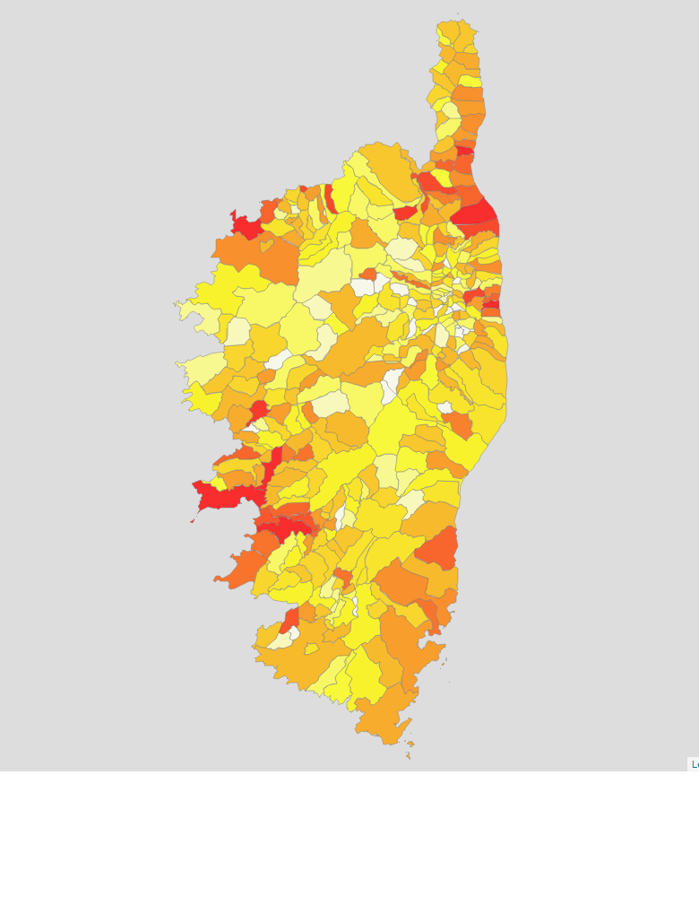

# 2) indic.menag

**Nombre de personnes par ménage (Source : INSEE, RP)**

**Données mises à jour (2019).**

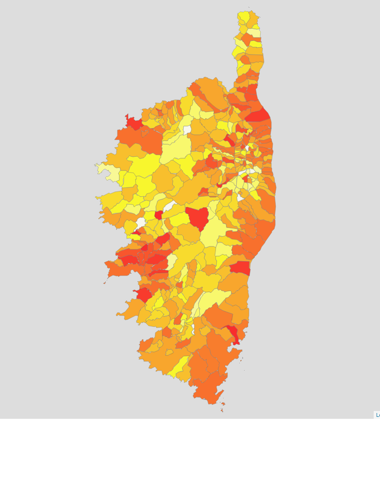

# 3) indic.rs

**Taux de résidences secondaires (Source : INSEE, RP)**

**Données mises à jour (2019).**

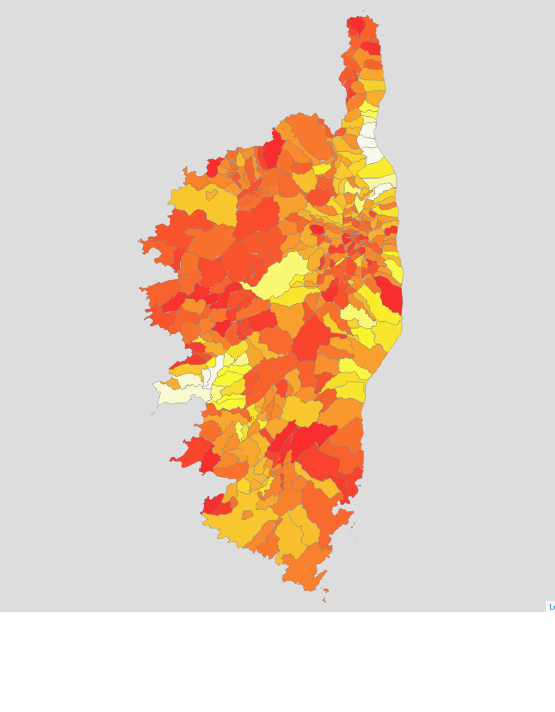

# 4) indic.lv

**Taux de logements vacants (Source : INSEE, RP)**

**Données mises à jour (2019).**

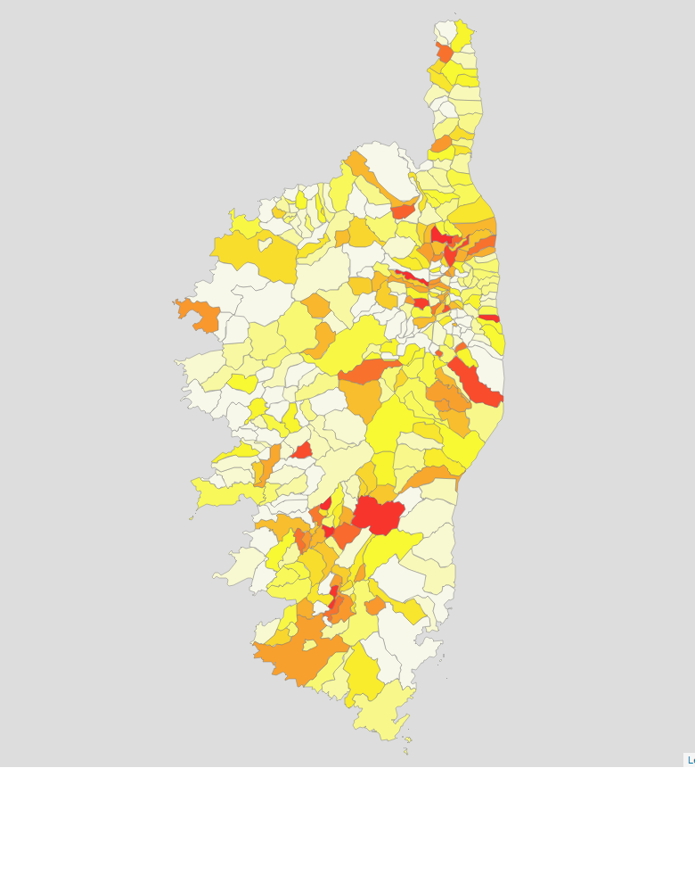

# 5) indic.jeun

**Jeunesse du parc (nombre de logements construits après 1975 rapporté au nombre de logements construits avant 1949), (Source : FILOCOM)**

Données mises à jour (2019). Attention : certaines valeurs trop faibles ont été secrétisées dans la base de données FILOCOM de 2019.  
Ces données ont été remplacées par des données fournies par l’INSEE qui correspondent au nombre de logements construits après 1970 rapporté au nombre de logements construits avant 1946.

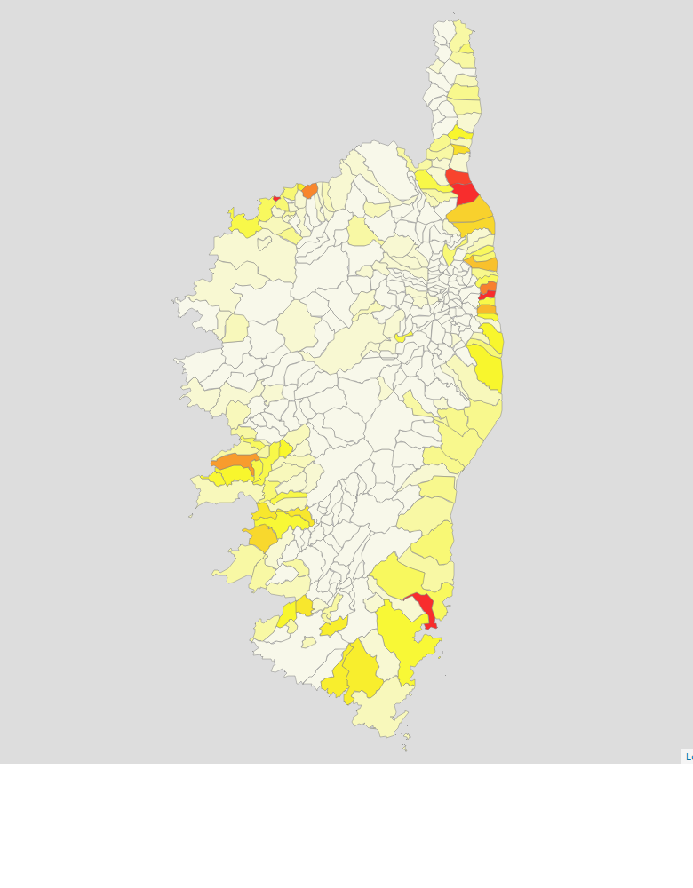

# 6) indic.social

**Taux de logements sociaux (Source : FILOCOM)**

Données mises à jour (2019). Attention : certaines valeurs trop faibles ont été secrétisées dans la base de données FILOCOM de 2019.  
Ces données ont été remplacées par les données de l’étude initiale (2017).

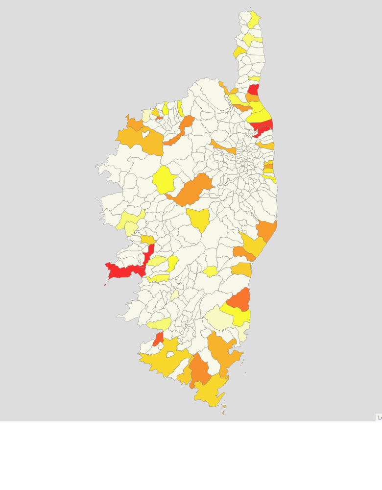

# 7) indic.prop

**Taux de logements occupés par leur propriétaire (Source : RP)**

Données mises à jour (2019). Le précédent indicateur a été construit à partir de la base FILOCOM 2017. Cependant certaines valeurs semble erronées. D’autre part, dans la base FILOCOM 2019 certaines valeurs trop faibles ont été secrétisées.  
Ainsi, il a été choisi de construire ce nouvel indicateur à partir du recensement de population INSEE de 2019.

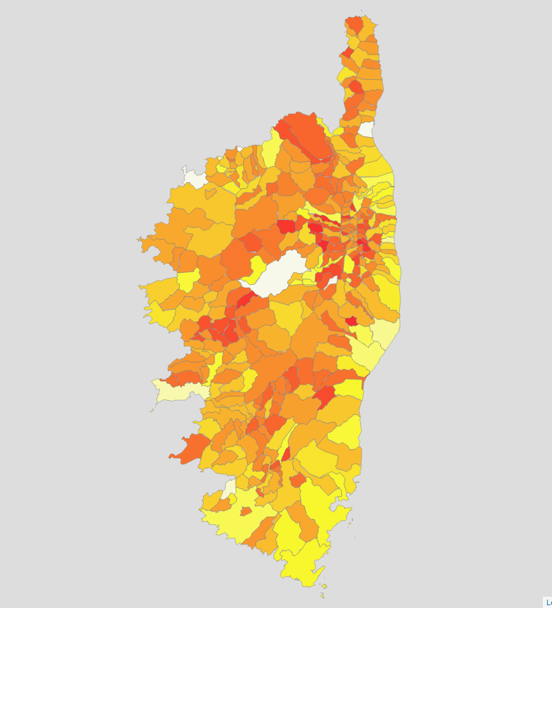

# 8) indic.duroc

**Durée d’occupation médiane des logements (Source : FILOCOM)**

Données mises à jour (2019). Attention : certaines valeurs trop faibles ont été secrétisées dans la base de données FILOCOM de 2019.  
Ces données ont été remplacées par les données de l’étude initiale (2017).

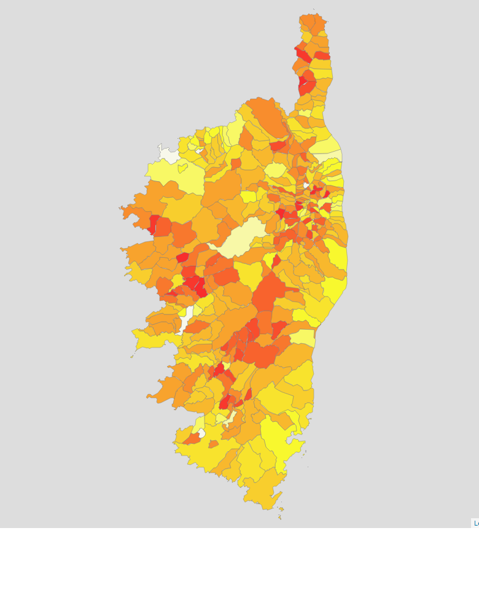

# 9) indic.prix

**Prix du mètre carré rapporté au revenu fiscal médian communal (Source : DV3F, FILOCOM)**

Données mises à jour (FILOCOM 2019 et DV3F 2018 - 2021).  
Le précédent indicateur portait sur le prix au mètre carré dans l’ancien, la mise à jour intègre également le neuf.

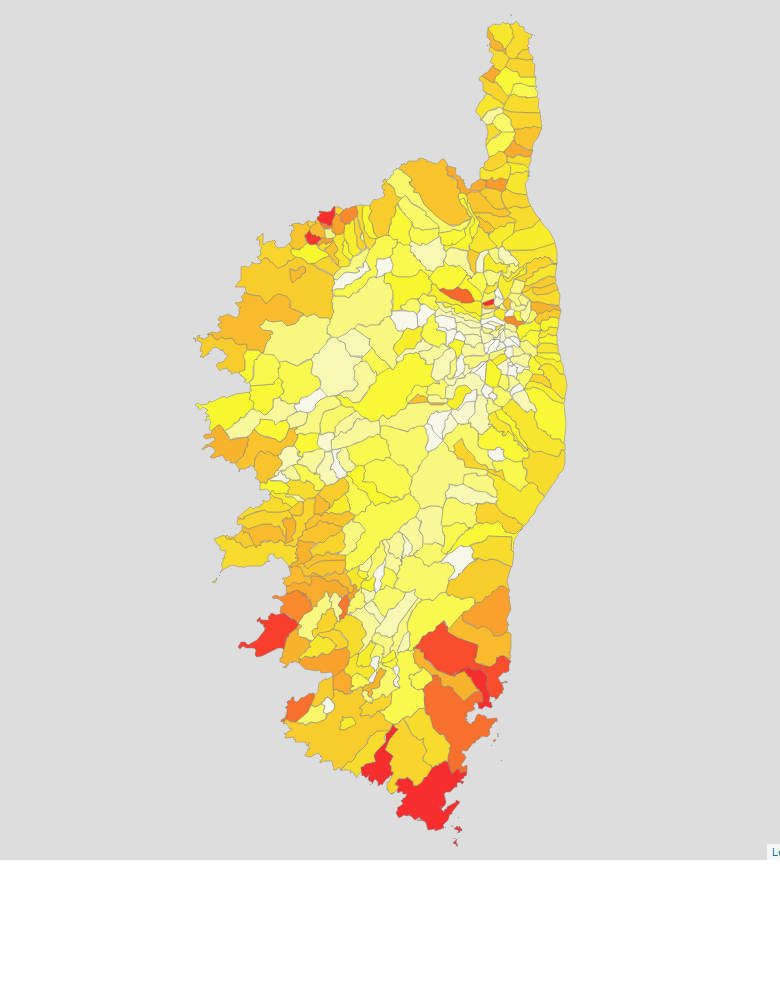

# 10) indic.airbnb.nb_lgmt

**Taux de locations touristiques de courte durée rapporté au parc de logements communal (Source : INSEE-RP, AirDNA)**

**Données mises à jour (2022).**

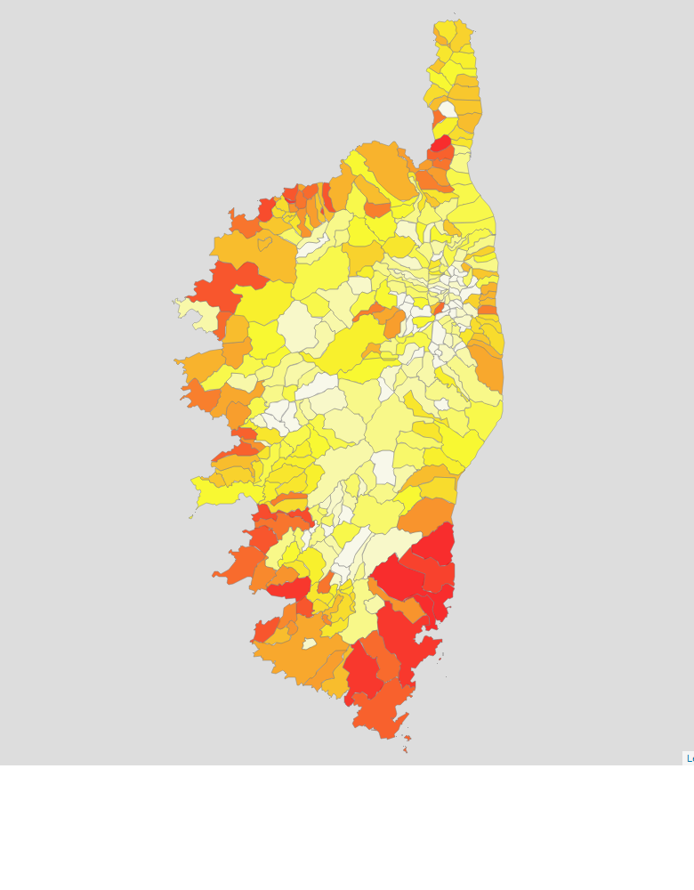

# 11) indic.airbnb.revTot_annee

**Revenu total généré par les locations touristiques de courte duréee (Source : AirDNA)**

**Nouvel indicateur qui peut être intégré dans les simulations à venir.**

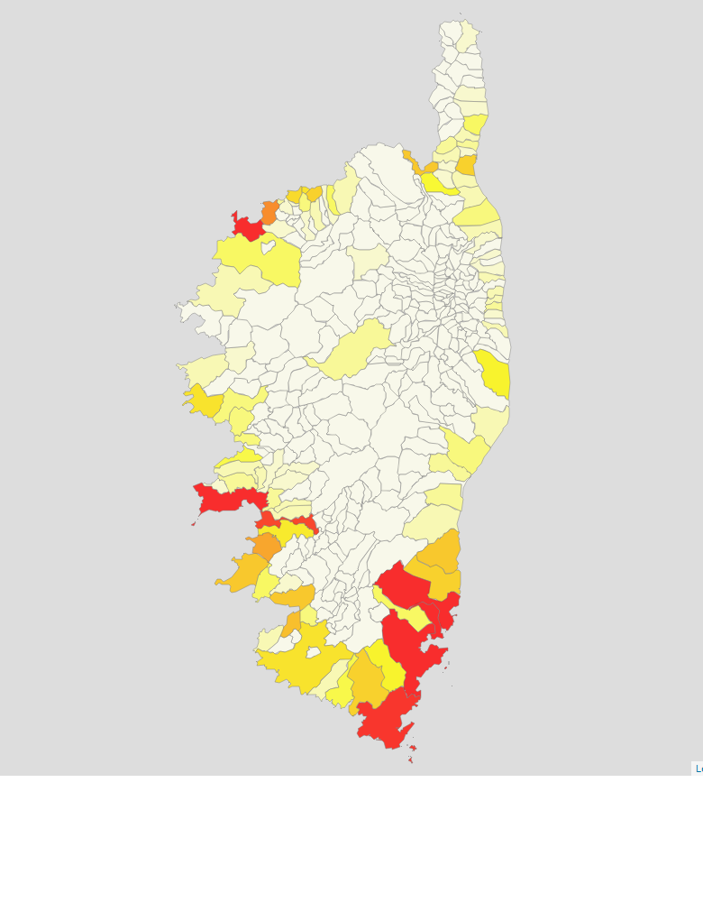

# 12) indic.airbnb.revMoy_lgt

**Revenu moyen par logement des locations touristiques de courte duréee (Source : AirDNA)**

**Nouvel indicateur qui peut être intégré dans les simulations à venir.**

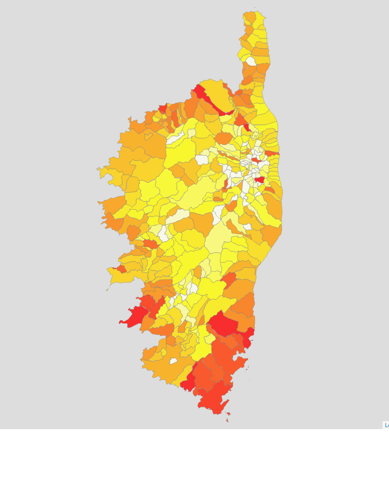

# 13) indic.log

**Nombre de logements (Source : INSEE, RP)**

**Nouvel indicateur qui peut être intégré dans les simulations à venir.**

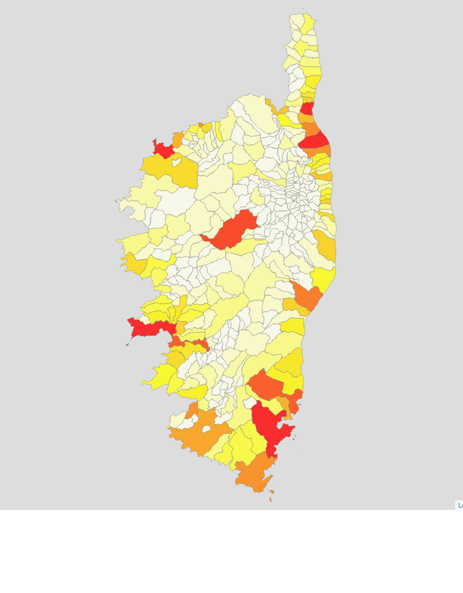